# DES_part3_#3724139

### 3724139

## Programming assignment - Part 3

```python
import part3_simstudy
```

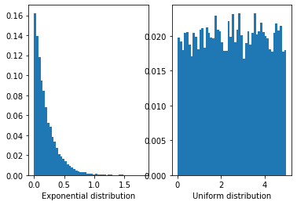

```python
part3_simstudy.task_3_2_1()
```

```python
part3_simstudy.task_3_2_2()
```

```
For t=100s system utilization values are:
rho=0.01 system utilization=0.00863116782248329
rho=0.5 system utilization=0.4610399884492721
rho=0.8 system utilization=0.7722862233645599
rho=0.9 system utilization=0.8393473829934212

For t=1000s system utilization values are:
rho=0.01 system utilization=0.010170094765077188
rho=0.5 system utilization=0.4692380128615397
rho=0.8 system utilization=0.760348871457988
rho=0.9 system utilization=0.8117480032841934
```

### Answers to Analysis and General Questions

#### Task 3.3.1

Random genrators don't really produce random numbers. Outputs are determind by the seed. Therefore, for running the same random generator with the same seed will give us similar results even on different machines.

#### Task 3.3.2

As it was stated in the lecture, depending on the number of bins we get the more accurate shape of a histogram. We should be careful while choosing the number of bins as we might loose information and end up with incorrect distribution if we choose too small or too large number of bins. If we have big number of bins the histogram has many peaks(or if there are fewer samples than bins, we have gaps) and with small number, there are fewer peaks and it is hard to determine which distribution we are dealing with. Sometimes it is better to combine some cells in order to end up with smoother histograms. As a rule of thumb in the lecture it was presented that we should take square root of the number of samples.